# Assignment 1: Data Wrangling and Visualization

Hector Ramirez Asturias

# 1. Setup and Data Loading

This analysis examines the CAN-PATH (Canadian Partnership for Tomorrow’s Health) synthetic data, exploring relationships between demographic factors and health outcomes.

## Load Required Libraries

```r
library(tidyverse)
```

## Load Data Files

```r
# Load demographics data
demographics <- read_csv("assignment1_can_path_demographics.csv")

# Load health data
health <- read_csv("assignment1_can_path_health.csv")

# Display dimensions
tibble(
  Dataset = c("Demographics", "Health"),
  Rows = c(nrow(demographics), nrow(health)),
  Columns = c(ncol(demographics), ncol(health))
)
```

```
## # A tibble: 2 × 3
##   Dataset       Rows Columns
##   <chr>        <int>   <int>
## 1 Demographics 41187       3
## 2 Health       41187       6
```

## Initial Data Inspection

```r
# Preview demographics
glimpse(demographics)
```

```
## Rows: 41,187
## Columns: 3
## $ ID         <chr> "SYN_58621", "SYN_58622", "SYN_58623", "SYN_58624", "SYN_58…
## $ SDC_GENDER <dbl> 2, 2, 2, 2, 2, 2, 2, 2, 2, 2, 1, 2, 2, 2, 2, 2, 2, 2, 2, 2,…
## $ SDC_INCOME <dbl> 6, 6, 4, 3, NA, 4, 5, 3, 3, 5, 8, NA, 3, 5, 4, 4, 4, NA, 4,…
```

```r
# Preview health
glimpse(health)
```

```
## Rows: 41,187
## Columns: 6
## $ ID              <chr> "SYN_58621", "SYN_58622", "SYN_58623", "SYN_58624", "S…
## $ HS_GEN_HEALTH   <dbl> 3, 4, 3, 4, 3, 5, 5, 3, 3, 4, 4, 4, 4, 5, 5, 3, 4, NA,…
## $ NUT_VEG_QTY     <dbl> 3, 0, 5, 1, 2, 5, 3, 5, 8, 1, 1, 3, 2, 2, 3, 1, 4, NA,…
## $ NUT_FRUITS_QTY  <dbl> 1, 0, 3, 3, 3, 5, 3, 2, 5, 0, 1, 5, 3, 1, 2, 1, 3, NA,…
## $ PA_TOTAL_SHORT  <dbl> 3564.0, 0.0, NA, 594.0, NA, NA, 2118.0, 297.0, NA, 240…
## $ DIS_ASTHMA_EVER <dbl> 0, 0, 2, 0, 1, 2, 0, NA, 0, 0, NA, 0, 0, 0, 0, 0, 0, 0…
```

# 2. Data Cleaning

## 2.1 Demographics Dataset Cleaning

### Check for Duplicates

```r
# Check for duplicate IDs
demo_duplicates <- demographics %>%
  group_by(ID) %>%
  filter(n() > 1)

tibble(Metric = "Duplicate IDs in demographics", Count = nrow(demo_duplicates))
```

```
## # A tibble: 1 × 2
##   Metric                        Count
##   <chr>                         <int>
## 1 Duplicate IDs in demographics     0
```

### Missing Values Analysis

```r
summary(demographics)
```

```
##       ID              SDC_GENDER      SDC_INCOME
##  Length:41187       Min.   :1.000   Min.   :1.000
##  Class :character   1st Qu.:1.000   1st Qu.:4.000
##  Mode  :character   Median :2.000   Median :5.000
##                     Mean   :1.631   Mean   :4.887
##                     3rd Qu.:2.000   3rd Qu.:6.000
##                     Max.   :2.000   Max.   :8.000
##                                     NA's   :5934
```

### Validate SDC_GENDER

```r
# SDC_GENDER should be 1 (Man) or 2 (Woman)
demographics %>%
  count(SDC_GENDER) %>%
  mutate(Percentage = round(n / sum(n) * 100, 2))
```

```
## # A tibble: 2 × 3
##   SDC_GENDER     n Percentage
##        <dbl> <int>      <dbl>
## 1          1 15200       36.9
## 2          2 25987       63.1
```

```r
# Check for invalid values
invalid_gender <- demographics %>%
  filter(!SDC_GENDER %in% c(1, 2, NA))

tibble(Metric = "Invalid gender values", Count = nrow(invalid_gender))
```

```
## # A tibble: 1 × 2
##   Metric                Count
##   <chr>                 <int>
## 1 Invalid gender values     0
```

### Validate SDC_INCOME

```r
# SDC_INCOME should be 1-8
demographics %>%
  count(SDC_INCOME) %>%
  mutate(Percentage = round(n / sum(n) * 100, 2))
```

```
## # A tibble: 9 × 3
##   SDC_INCOME     n Percentage
##        <dbl> <int>      <dbl>
## 1          1   472       1.15
## 2          2  1985       4.82
## 3          3  5745      14.0
## 4          4  6831      16.6
## 5          5  6602      16.0
## 6          6  7600      18.4
## 7          7  3463       8.41
## 8          8  2555       6.2
## 9         NA  5934      14.4
```

```r
# Check for invalid values (outside 1-8 range)
invalid_income <- demographics %>%
  filter(!SDC_INCOME %in% c(1:8, NA))

tibble(Metric = "Invalid income values", Count = nrow(invalid_income))
```

```
## # A tibble: 1 × 2
##   Metric                Count
##   <chr>                 <int>
## 1 Invalid income values     0
```

### Clean Demographics Data

```r
# Create cleaned demographics dataset
demographics_clean <- demographics %>%
  # Remove any duplicate IDs (keep first occurrence)
  distinct(ID, .keep_all = TRUE) %>%
  # Filter to valid gender values only
  filter(SDC_GENDER %in% c(1, 2)) %>%
  # Add descriptive labels using case_when
  mutate(
    Gender = case_when(
      SDC_GENDER == 1 ~ "Man",
      SDC_GENDER == 2 ~ "Woman"
    ),
    Income_Category = case_when(
      SDC_INCOME == 1 ~ "1_Less than 10 000 $",
      SDC_INCOME == 2 ~ "2_10 000 $ - 24 999 $",
      SDC_INCOME == 3 ~ "3_25 000 $ - 49 999 $",
      SDC_INCOME == 4 ~ "4_50 000 $ - 74 999 $",
      SDC_INCOME == 5 ~ "5_75 000 $ - 99 999 $",
      SDC_INCOME == 6 ~ "6_100 000 $ - 149 999 $",
      SDC_INCOME == 7 ~ "7_150 000 $ - 199 999 $",
      SDC_INCOME == 8 ~ "8_200 000 $ or more"
    )
  )

# Verify recoding
table(demographics_clean$SDC_GENDER, demographics_clean$Gender)
```

```
##
##       Man Woman
##   1 15200     0
##   2     0 25987
```

```r
table(demographics_clean$SDC_INCOME, demographics_clean$Income_Category)
```

```
##
##     1_Less than 10 000 $ 2_10 000 $ - 24 999 $ 3_25 000 $ - 49 999 $
##   1                  472                     0                     0
##   2                    0                  1985                     0
##   3                    0                     0                  5745
##   4                    0                     0                     0
##   5                    0                     0                     0
##   6                    0                     0                     0
##   7                    0                     0                     0
##   8                    0                     0                     0
##
##     4_50 000 $ - 74 999 $ 5_75 000 $ - 99 999 $ 6_100 000 $ - 149 999 $
##   1                     0                     0                       0
##   2                     0                     0                       0
##   3                     0                     0                       0
##   4                  6831                     0                       0
##   5                     0                  6602                       0
##   6                     0                     0                    7600
##   7                     0                     0                       0
##   8                     0                     0                       0
##
##     7_150 000 $ - 199 999 $ 8_200 000 $ or more
##   1                       0                   0
##   2                       0                   0
##   3                       0                   0
##   4                       0                   0
##   5                       0                   0
##   6                       0                   0
##   7                    3463                   0
##   8                       0                2555
```

```r
tibble(Metric = "Demographics after cleaning", Rows = nrow(demographics_clean))
```

```
## # A tibble: 1 × 2
##   Metric                       Rows
##   <chr>                       <int>
## 1 Demographics after cleaning 41187
```

## 2.2 Health Dataset Cleaning

### Check for Duplicates

```r
# Check for duplicate IDs
health_duplicates <- health %>%
  group_by(ID) %>%
  filter(n() > 1)

tibble(Metric = "Duplicate IDs in health", Count = nrow(health_duplicates))
```

```
## # A tibble: 1 × 2
##   Metric                  Count
##   <chr>                   <int>
## 1 Duplicate IDs in health     0
```

### Missing Values Analysis

```r
summary(health)
```

```
##       ID            HS_GEN_HEALTH    NUT_VEG_QTY     NUT_FRUITS_QTY
##  Length:41187       Min.   :1.000   Min.   : 0.000   Min.   : 0.000
##  Class :character   1st Qu.:3.000   1st Qu.: 2.000   1st Qu.: 1.000
##  Mode  :character   Median :4.000   Median : 2.000   Median : 2.000
##                     Mean   :3.638   Mean   : 2.672   Mean   : 2.132
##                     3rd Qu.:4.000   3rd Qu.: 3.000   3rd Qu.: 3.000
##                     Max.   :5.000   Max.   :35.000   Max.   :25.000
##                     NA's   :672     NA's   :2549     NA's   :2426
##  PA_TOTAL_SHORT  DIS_ASTHMA_EVER
##  Min.   :    0   Min.   :0.0000
##  1st Qu.:  600   1st Qu.:0.0000
##  Median : 1782   Median :0.0000
##  Mean   : 2574   Mean   :0.2039
##  3rd Qu.: 3732   3rd Qu.:0.0000
##  Max.   :19278   Max.   :2.0000
##  NA's   :6763    NA's   :1228
```

### Validate Categorical Variables

```r
# HS_GEN_HEALTH: Self-rated health (1 = Excellent to 5 = Poor)
health %>%
  count(HS_GEN_HEALTH) %>%
  mutate(Percentage = round(n / sum(n) * 100, 2))
```

```
## # A tibble: 6 × 3
##   HS_GEN_HEALTH     n Percentage
##           <dbl> <int>      <dbl>
## 1             1   808       1.96
## 2             2  3290       7.99
## 3             3 12572      30.5
## 4             4 16938      41.1
## 5             5  6907      16.8
## 6            NA   672       1.63
```

```r
# DIS_ASTHMA_EVER: 0 = No, 1 = Yes, 2 = Don't know
health %>%
  count(DIS_ASTHMA_EVER) %>%
  mutate(Percentage = round(n / sum(n) * 100, 2))
```

```
## # A tibble: 4 × 3
##   DIS_ASTHMA_EVER     n Percentage
##             <dbl> <int>      <dbl>
## 1               0 33275      80.8
## 2               1  5221      12.7
## 3               2  1463       3.55
## 4              NA  1228       2.98
```

### Identify Outliers in Physical Activity

```r
# Summary statistics for PA_TOTAL_SHORT
pa_summary <- health %>%
  filter(!is.na(PA_TOTAL_SHORT)) %>%
  summarise(
    Min = min(PA_TOTAL_SHORT),
    Q1 = quantile(PA_TOTAL_SHORT, 0.25),
    Median = median(PA_TOTAL_SHORT),
    Mean = mean(PA_TOTAL_SHORT),
    Q3 = quantile(PA_TOTAL_SHORT, 0.75),
    Max = max(PA_TOTAL_SHORT),
    SD = sd(PA_TOTAL_SHORT)
  )

pa_summary %>% print()
```

```
## # A tibble: 1 × 7
##     Min    Q1 Median  Mean    Q3   Max    SD
##   <dbl> <dbl>  <dbl> <dbl> <dbl> <dbl> <dbl>
## 1     0   600   1782 2574.  3732 19278 2656.
```

```r
# Calculate IQR and identify outliers
IQR_val <- IQR(health$PA_TOTAL_SHORT, na.rm = TRUE)
Q1 <- quantile(health$PA_TOTAL_SHORT, 0.25, na.rm = TRUE)
Q3 <- quantile(health$PA_TOTAL_SHORT, 0.75, na.rm = TRUE)

lower_bound <- Q1 - 1.5 * IQR_val
upper_bound <- Q3 + 1.5 * IQR_val

tibble(
  Metric = c("Lower bound", "Upper bound"),
  Value = c(lower_bound, upper_bound)
)
```

```
## # A tibble: 2 × 2
##   Metric      Value
##   <chr>       <dbl>
## 1 Lower bound -4098
## 2 Upper bound  8430
```

```r
# Count outliers
outliers <- health %>%
  filter(!is.na(PA_TOTAL_SHORT)) %>%
  filter(PA_TOTAL_SHORT < lower_bound | PA_TOTAL_SHORT > upper_bound)

tibble(
  Metric = c("Outliers identified", "Percentage of total"),
  Value = c(nrow(outliers), round(nrow(outliers) / sum(!is.na(health$PA_TOTAL_SHORT)) * 100, 2))
)
```

```
## # A tibble: 2 × 2
##   Metric                Value
##   <chr>                 <dbl>
## 1 Outliers identified 1455
## 2 Percentage of total    4.23
```

### Clean Health Data

```r
# Create cleaned health dataset
health_clean <- health %>%
  # Remove any duplicate IDs (keep first occurrence)
  distinct(ID, .keep_all = TRUE) %>%
  # Filter to valid general health values
  filter(HS_GEN_HEALTH %in% 1:5 | is.na(HS_GEN_HEALTH)) %>%
  # Filter to valid asthma values
  filter(DIS_ASTHMA_EVER %in% c(0, 1, 2) | is.na(DIS_ASTHMA_EVER)) %>%
  # Add descriptive labels using case_when
  mutate(
    General_Health = case_when(
      HS_GEN_HEALTH == 1 ~ "1_Excellent",
      HS_GEN_HEALTH == 2 ~ "2_Very Good",
      HS_GEN_HEALTH == 3 ~ "3_Good",
      HS_GEN_HEALTH == 4 ~ "4_Fair",
      HS_GEN_HEALTH == 5 ~ "5_Poor"
    ),
    Asthma_History = case_when(
      DIS_ASTHMA_EVER == 0 ~ "No",
      DIS_ASTHMA_EVER == 1 ~ "Yes",
      DIS_ASTHMA_EVER == 2 ~ "Don't Know"
    )
  )

# Verify recoding
table(health_clean$HS_GEN_HEALTH, health_clean$General_Health)
```

```
##
##     1_Excellent 2_Very Good 3_Good 4_Fair 5_Poor
##   1         808           0      0      0      0
##   2           0        3290      0      0      0
##   3           0           0  12572      0      0
##   4           0           0      0  16938      0
##   5           0           0      0      0   6907
```

```r
table(health_clean$DIS_ASTHMA_EVER, health_clean$Asthma_History)
```

```
##
##     Don't Know    No   Yes
##   0          0 33275     0
##   1          0     0  5221
##   2       1463     0     0
```

```r
tibble(Metric = "Health after cleaning", Rows = nrow(health_clean))
```

```
## # A tibble: 1 × 2
##   Metric                 Rows
##   <chr>                 <int>
## 1 Health after cleaning 41187
```

# 3. Join Datasets

## Perform Inner Join

An **inner join** was used to combine the datasets on ID, retaining records present in both sources. This ensures complete data for analysis.

```r
# Perform inner join on ID
combined_data <- demographics_clean %>%
  inner_join(health_clean, by = "ID")

tibble(
  Metric = c("Combined dataset rows", "Combined dataset columns"),
  Value = c(nrow(combined_data), ncol(combined_data))
)
```

```
## # A tibble: 2 × 2
##   Metric                   Value
##   <chr>                    <int>
## 1 Combined dataset rows    41187
## 2 Combined dataset columns    12
```

## Verify Join Results

```r
# Check for records that didn't match
demo_not_matched <- demographics_clean %>%
  anti_join(health_clean, by = "ID")

health_not_matched <- health_clean %>%
  anti_join(demographics_clean, by = "ID")

tibble(
  Dataset = c("Demographics not matched", "Health not matched"),
  Count = c(nrow(demo_not_matched), nrow(health_not_matched))
)
```

```
## # A tibble: 2 × 2
##   Dataset                  Count
##   <chr>                    <int>
## 1 Demographics not matched     0
## 2 Health not matched           0
```

```r
# Summary of combined data
glimpse(combined_data)
```

```
## Rows: 41,187
## Columns: 12
## $ ID              <chr> "SYN_58621", "SYN_58622", "SYN_58623", "SYN_58624", "S…
## $ SDC_GENDER      <dbl> 2, 2, 2, 2, 2, 2, 2, 2, 2, 2, 1, 2, 2, 2, 2, 2, 2, 2, …
## $ SDC_INCOME      <dbl> 6, 6, 4, 3, NA, 4, 5, 3, 3, 5, 8, NA, 3, 5, 4, 4, 4, N…
## $ Gender          <chr> "Woman", "Woman", "Woman", "Woman", "Woman", "Woman", …
## $ Income_Category <chr> "6_100 000 $ - 149 999 $", "6_100 000 $ - 149 999 $", …
## $ HS_GEN_HEALTH   <dbl> 3, 4, 3, 4, 3, 5, 5, 3, 3, 4, 4, 4, 4, 5, 5, 3, 4, NA,…
## $ NUT_VEG_QTY     <dbl> 3, 0, 5, 1, 2, 5, 3, 5, 8, 1, 1, 3, 2, 2, 3, 1, 4, NA,…
## $ NUT_FRUITS_QTY  <dbl> 1, 0, 3, 3, 3, 5, 3, 2, 5, 0, 1, 5, 3, 1, 2, 1, 3, NA,…
## $ PA_TOTAL_SHORT  <dbl> 3564.0, 0.0, NA, 594.0, NA, NA, 2118.0, 297.0, NA, 240…
## $ DIS_ASTHMA_EVER <dbl> 0, 0, 2, 0, 1, 2, 0, NA, 0, 0, NA, 0, 0, 0, 0, 0, 0, 0…
## $ General_Health  <chr> "3_Good", "4_Fair", "3_Good", "4_Fair", "3_Good", "5_P…
## $ Asthma_History  <chr> "No", "No", "Don't Know", "No", "Yes", "Don't Know", "…
```

## Data Quality Check Post-Join

```r
summary(combined_data)
```

```
##       ID              SDC_GENDER      SDC_INCOME       Gender
##  Length:41187       Min.   :1.000   Min.   :1.000   Length:41187
##  Class :character   1st Qu.:1.000   1st Qu.:4.000   Class :character
##  Mode  :character   Median :2.000   Median :5.000   Mode  :character
##                     Mean   :1.631   Mean   :4.887
##                     3rd Qu.:2.000   3rd Qu.:6.000
##                     Max.   :2.000   Max.   :8.000
##                                     NA's   :5934
##  Income_Category    HS_GEN_HEALTH    NUT_VEG_QTY     NUT_FRUITS_QTY
##  Length:41187       Min.   :1.000   Min.   : 0.000   Min.   : 0.000
##  Class :character   1st Qu.:3.000   1st Qu.: 2.000   1st Qu.: 1.000
##  Mode  :character   Median :4.000   Median : 2.000   Median : 2.000
##                     Mean   :3.638   Mean   : 2.672   Mean   : 2.132
##                     3rd Qu.:4.000   3rd Qu.: 3.000   3rd Qu.: 3.000
##                     Max.   :5.000   Max.   :35.000   Max.   :25.000
##                     NA's   :672     NA's   :2549     NA's   :2426
##  PA_TOTAL_SHORT  DIS_ASTHMA_EVER  General_Health     Asthma_History
##  Min.   :    0   Min.   :0.0000   Length:41187       Length:41187
##  1st Qu.:  600   1st Qu.:0.0000   Class :character   Class :character
##  Median : 1782   Median :0.0000   Mode  :character   Mode  :character
##  Mean   : 2574   Mean   :0.2039
##  3rd Qu.: 3732   3rd Qu.:0.0000
##  Max.   :19278   Max.   :2.0000
##  NA's   :6763    NA's   :1228
```

# 4. Descriptive Statistics

## 4.1 Continuous Variables

### Physical Activity (PA_TOTAL_SHORT)

```r
summary(combined_data$PA_TOTAL_SHORT)
```

```
##    Min. 1st Qu.  Median    Mean 3rd Qu.    Max.    NA's
##       0     600    1782    2574    3732   19278    6763
```

### Vegetable Consumption (NUT_VEG_QTY)

```r
summary(combined_data$NUT_VEG_QTY)
```

```
##    Min. 1st Qu.  Median    Mean 3rd Qu.    Max.    NA's
##   0.000   2.000   2.000   2.672   3.000  35.000    2549
```

### Fruit Consumption (NUT_FRUITS_QTY)

```r
summary(combined_data$NUT_FRUITS_QTY)
```

```
##    Min. 1st Qu.  Median    Mean 3rd Qu.    Max.    NA's
##   0.000   1.000   2.000   2.132   3.000  25.000    2426
```

## 4.2 Categorical Variables

### Gender Distribution

```r
combined_data %>%
  count(Gender) %>%
  mutate(Percentage = round(n / sum(n) * 100, 2))
```

```
## # A tibble: 2 × 3
##   Gender     n Percentage
##   <chr>  <int>      <dbl>
## 1 Man    15200       36.9
## 2 Woman  25987       63.1
```

### Income Distribution

```r
combined_data %>%
  filter(!is.na(Income_Category)) %>%
  count(Income_Category) %>%
  mutate(Percentage = round(n / sum(n) * 100, 2))
```

```
## # A tibble: 8 × 3
##   Income_Category             n Percentage
##   <chr>                   <int>      <dbl>
## 1 1_Less than 10 000 $      472       1.34
## 2 2_10 000 $ - 24 999 $    1985       5.63
## 3 3_25 000 $ - 49 999 $    5745      16.3
## 4 4_50 000 $ - 74 999 $    6831      19.4
## 5 5_75 000 $ - 99 999 $    6602      18.7
## 6 6_100 000 $ - 149 999 $  7600      21.6
## 7 7_150 000 $ - 199 999 $  3463       9.82
## 8 8_200 000 $ or more      2555       7.25
```

### General Health Distribution

```r
combined_data %>%
  filter(!is.na(General_Health)) %>%
  count(General_Health) %>%
  mutate(Percentage = round(n / sum(n) * 100, 2))
```

```
## # A tibble: 5 × 3
##   General_Health     n Percentage
##   <chr>          <int>      <dbl>
## 1 1_Excellent      808       1.99
## 2 2_Very Good     3290       8.12
## 3 3_Good         12572      31.0
## 4 4_Fair         16938      41.8
## 5 5_Poor          6907      17.0
```

# 5. Visualizations

## 5.1 Physical Activity Distribution (Histogram)

This histogram shows the distribution of total physical activity levels in the sample. The distribution is right-skewed, indicating most participants have low to moderate physical activity levels.

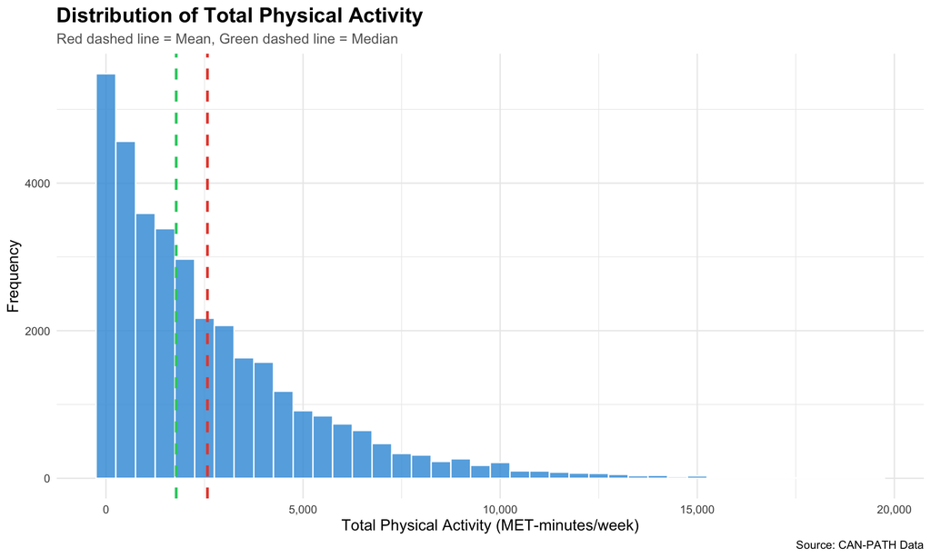

```r
pa_histogram <- ggplot(combined_data %>% filter(!is.na(PA_TOTAL_SHORT)), aes(x = PA_TOTAL_SHORT)) +
  geom_histogram(binwidth = 500, fill = "#3498db", color = "white", alpha = 0.8) +
  geom_vline(aes(xintercept = mean(PA_TOTAL_SHORT)),
             color = "#e74c3c", linetype = "dashed", linewidth = 1) +
  geom_vline(aes(xintercept = median(PA_TOTAL_SHORT)),
             color = "#2ecc71", linetype = "dashed", linewidth = 1) +
  labs(
    title = "Distribution of Total Physical Activity",
    subtitle = "Red dashed line = Mean, Green dashed line = Median",
    x = "Total Physical Activity (MET-minutes/week)",
    y = "Frequency",
    caption = "Source: CAN-PATH Data"
  ) +
  theme_minimal() +
  theme(
    plot.title = element_text(size = 16, face = "bold"),
    plot.subtitle = element_text(size = 11, color = "gray40"),
    axis.title = element_text(size = 12)
  ) +
  scale_x_continuous(labels = scales::comma)
plot(pa_histogram)
```

## 5.2 Income Distribution by Gender (Grouped Bar Chart)

This grouped bar chart compares income distribution between males and females. This visualization compares income distributions across gender categories.

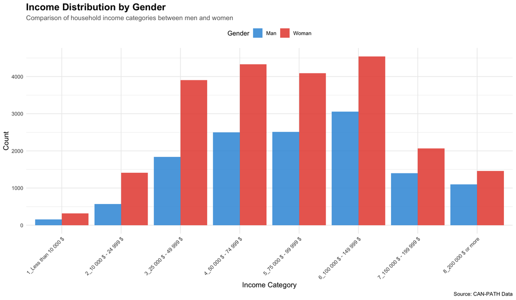

```r
income_bar <- ggplot(combined_data %>% filter(!is.na(Income_Category) & !is.na(Gender)) %>%
                       count(Income_Category, Gender),
                     aes(x = Income_Category, y = n, fill = Gender)) +
  geom_bar(stat = "identity", position = "dodge", alpha = 0.85) +
  scale_fill_manual(values = c("Man" = "#3498db", "Woman" = "#e74c3c")) +
  labs(
    title = "Income Distribution by Gender",
    subtitle = "Comparison of household income categories between men and women",
    x = "Income Category",
    y = "Count",
    fill = "Gender",
    caption = "Source: CAN-PATH Data"
  ) +
  theme_minimal() +
  theme(
    plot.title = element_text(size = 16, face = "bold"),
    plot.subtitle = element_text(size = 11, color = "gray40"),
    axis.title = element_text(size = 12),
    axis.text.x = element_text(angle = 45, hjust = 1),
    legend.position = "top"
  )
plot(income_bar)
```

## 5.3 Nutrition vs Physical Activity (Scatterplot)

This scatterplot explores the relationship between fruit/vegetable consumption and physical activity, colored by general health status.

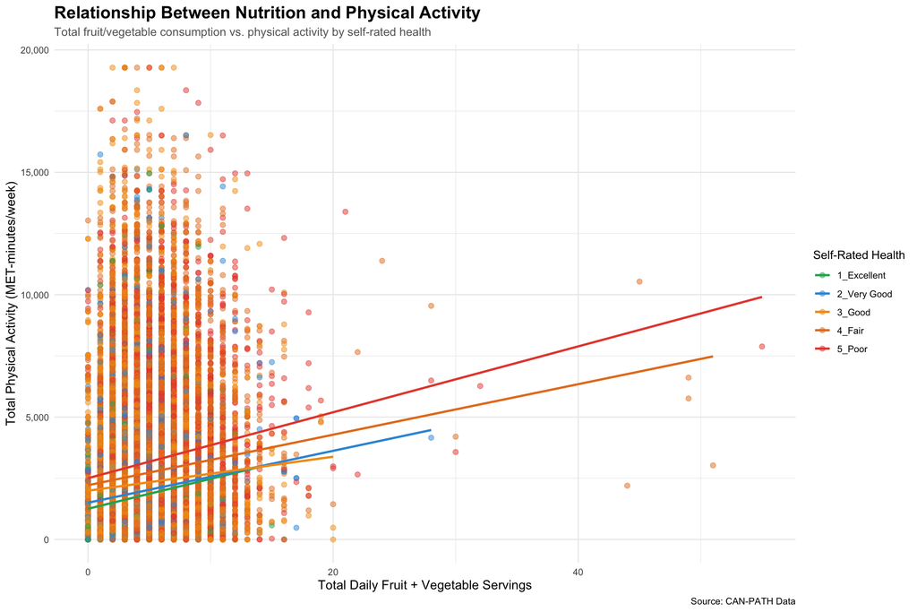

```r
# Create combined nutrition variable
nutrition_scatter <- ggplot(combined_data %>%
                              filter(!is.na(PA_TOTAL_SHORT) & !is.na(NUT_VEG_QTY) &
                                     !is.na(NUT_FRUITS_QTY) & !is.na(General_Health)) %>%
                              mutate(Total_FruitVeg = NUT_VEG_QTY + NUT_FRUITS_QTY),
                            aes(x = Total_FruitVeg, y = PA_TOTAL_SHORT, color = General_Health)) +
  geom_point(alpha = 0.5, size = 2) +
  geom_smooth(method = "lm", se = FALSE, aes(group = General_Health), linewidth = 1) +
  scale_color_manual(values = c("1_Excellent" = "#27ae60",
                                "2_Very Good" = "#3498db",
                                "3_Good" = "#f39c12",
                                "4_Fair" = "#e67e22",
                                "5_Poor" = "#e74c3c")) +
  labs(
    title = "Relationship Between Nutrition and Physical Activity",
    subtitle = "Total fruit/vegetable consumption vs. physical activity by self-rated health",
    x = "Total Daily Fruit + Vegetable Servings",
    y = "Total Physical Activity (MET-minutes/week)",
    color = "Self-Rated Health",
    caption = "Source: CAN-PATH Data"
  ) +
  theme_minimal() +
  theme(
    plot.title = element_text(size = 16, face = "bold"),
    plot.subtitle = element_text(size = 11, color = "gray40"),
    axis.title = element_text(size = 12),
    legend.position = "right"
  ) +
  scale_y_continuous(labels = scales::comma)
plot(nutrition_scatter)
```

## 5.4 Physical Activity by Income Category (Boxplot)

This boxplot shows the distribution of physical activity across income categories.

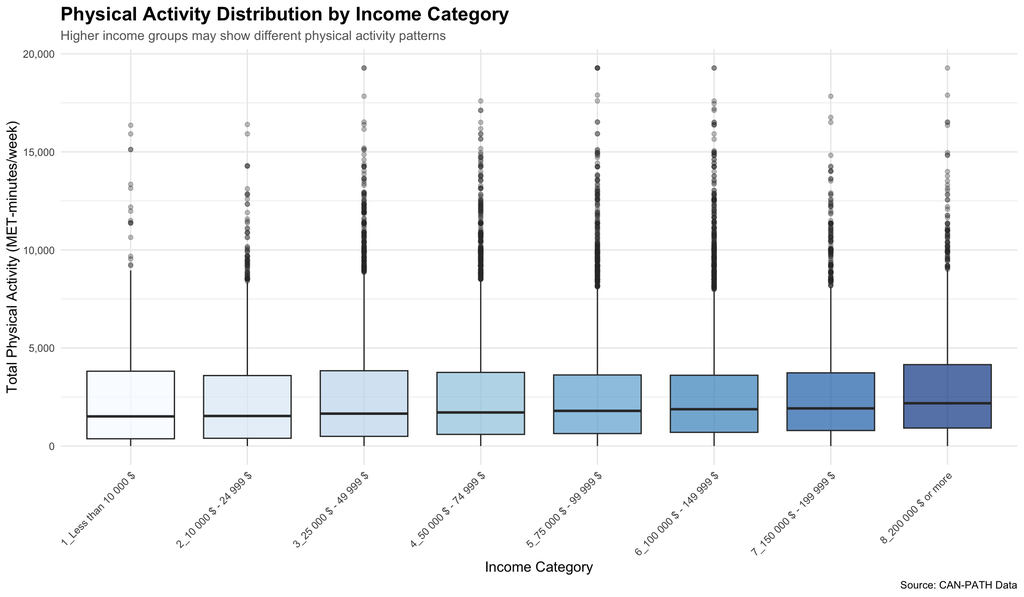

```r
pa_boxplot <- ggplot(combined_data %>% filter(!is.na(PA_TOTAL_SHORT) & !is.na(Income_Category)),
                     aes(x = Income_Category, y = PA_TOTAL_SHORT, fill = Income_Category)) +
  geom_boxplot(alpha = 0.7, outlier.alpha = 0.3) +
  scale_fill_brewer(palette = "Blues") +
  labs(
    title = "Physical Activity Distribution by Income Category",
    subtitle = "Higher income groups may show different physical activity patterns",
    x = "Income Category",
    y = "Total Physical Activity (MET-minutes/week)",
    caption = "Source: CAN-PATH Data"
  ) +
  theme_minimal() +
  theme(
    plot.title = element_text(size = 16, face = "bold"),
    plot.subtitle = element_text(size = 11, color = "gray40"),
    axis.title = element_text(size = 12),
    axis.text.x = element_text(angle = 45, hjust = 1),
    legend.position = "none"
  ) +
  scale_y_continuous(labels = scales::comma)
plot(pa_boxplot)
```

## 5.5 Health Status by Gender (Faceted Plot)

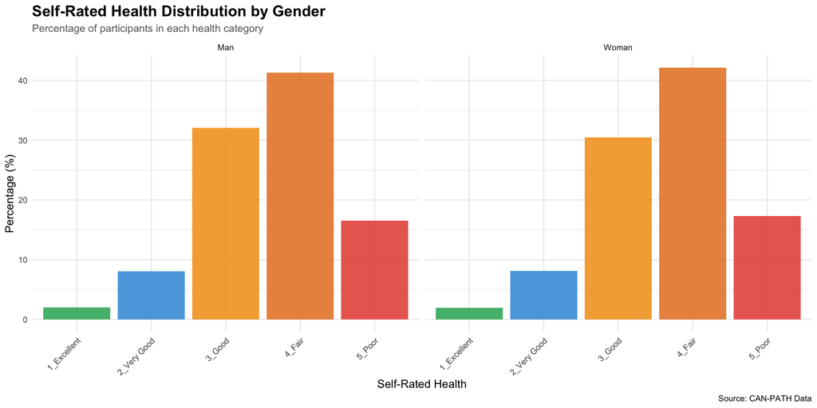

```r
health_facet <- ggplot(combined_data %>%
                         filter(!is.na(General_Health) & !is.na(Gender)) %>%
                         count(Gender, General_Health) %>%
                         group_by(Gender) %>%
                         mutate(Percentage = n / sum(n) * 100),
                       aes(x = General_Health, y = Percentage, fill = General_Health)) +
  geom_bar(stat = "identity", alpha = 0.85) +
  facet_wrap(~Gender) +
  scale_fill_manual(values = c("1_Excellent" = "#27ae60",
                               "2_Very Good" = "#3498db",
                               "3_Good" = "#f39c12",
                               "4_Fair" = "#e67e22",
                               "5_Poor" = "#e74c3c")) +
  labs(
    title = "Self-Rated Health Distribution by Gender",
    subtitle = "Percentage of participants in each health category",
    x = "Self-Rated Health",
    y = "Percentage (%)",
    caption = "Source: CAN-PATH Data"
  ) +
  theme_minimal() +
  theme(
    plot.title = element_text(size = 16, face = "bold"),
    plot.subtitle = element_text(size = 11, color = "gray40"),
    axis.title = element_text(size = 12),
    axis.text.x = element_text(angle = 45, hjust = 1),
    legend.position = "none"
  )
plot(health_facet)
```

# 6. Summary and Findings

## Data Processing Summary

- The demographics dataset contained 41187 observations with variables for gender and income
- The health dataset contained 41187 observations with physical activity, nutrition, and health status measures
- After cleaning and joining, 41187 records were retained. Several variables contain missing values (e.g., income and physical activity), which were handled using available-case analysis for descriptive summaries and plots.

## Sample Characteristics

- The sample is predominantly women (63.1%)
- Income distribution across categories is shown in the descriptive statistics section

## Variable Distributions

- Physical activity (PA_TOTAL_SHORT) shows a right-skewed distribution, as visualized in the histogram
- The descriptive statistics and visualizations provide an overview of the distributions for all continuous and categorical variables

## Limitations

- This is a descriptive analysis only; no inferential statistics or hypothesis testing were performed
- Cross-sectional data cannot establish temporal relationships or causation
- Analyses were primarily conducted using available observations for each variable/plot (pairwise/available-case), which may affect comparability across summaries if missing data is systematic.
- Self-reported measures (physical activity, nutrition) may be subject to recall bias and social desirability bias
- The synthetic nature of this dataset limits external validity